# Calculando a Volatilidade Implícita e as Gregas no R

Uma aplicação com opções da B3 · Análise Macro

Autor

Luiz Henrique / Análise Macro

## 1 Introdução

A volatilidade implícita é um dos conceitos mais monitorados na análise de derivativos financeiros. Diferente da volatilidade histórica, que olha para o passado do ativo, a volatilidade implícita é uma estimativa *forward-looking* (voltada para o futuro). Ela representa a expectativa do mercado quanto à magnitude das oscilações do preço de um ativo subjacente, embutida no preço atual de suas opções.

Neste guia exploramos a fundamentação teórica da precificação de opções e mostramos como o ecossistema da linguagem **R** permite extrair, processar e calcular a volatilidade implícita e as “gregas” para ativos listados na B3, usando como estudo de caso as opções da Vale (VALE3).

## 2 Fundamentos: opções e o modelo de Black-Scholes

Uma opção financeira é um contrato derivativo que confere ao titular o direito, mas não a obrigação, de comprar (*call*) ou vender (*put*) um ativo subjacente a um preço predeterminado (*strike*) em uma data futura. Esses instrumentos são vitais para estratégias de *hedge* (proteção), especulação direcional e arbitragem de volatilidade.

A precificação desses contratos ganhou base formal em 1973, com o **modelo de Black-Scholes** de Fischer Black, Myron Scholes e Robert Merton. O modelo determina o preço justo (teórico) de uma opção europeia a partir de cinco variáveis: preço à vista do ativo ($S$), preço de exercício ($K$), prazo até o vencimento ($T$), taxa de juros livre de risco ($r$) e volatilidade ($\sigma$). O preço de uma *call* é:

$$C = S\,N(d_1) - K e^{-rT} N(d_2)$$

$$d_1 = \frac{\ln(S/K) + (r + \sigma^2/2)\,T}{\sigma\sqrt{T}}, \qquad d_2 = d_1 - \sigma\sqrt{T}$$

onde $N(\cdot)$ é a função de distribuição acumulada da normal padrão.

No mercado real, o preço da opção já é dado pelo encontro entre oferta e demanda no *book* de ofertas. Por isso a utilidade prática do modelo se inverte: inserimos o preço de mercado da opção na equação para descobrir a única variável não observável diretamente, a **volatilidade implícita**. Quando ela aumenta, o prêmio da opção encarece, pois o mercado precifica maior probabilidade de variações bruscas do ativo.

## 3 As gregas: mensurando a sensibilidade

As “gregas” quantificam a sensibilidade do prêmio da opção a choques em suas variáveis:

- **Delta:** sensibilidade direcional. Quanto o preço da opção varia para cada R$ 1,00 no ativo. Varia de 0 a 1 nas *calls* e de −1 a 0 nas *puts*.
- **Gama:** a taxa de variação do próprio Delta em relação ao ativo — a convexidade da opção.
- **Theta:** o decaimento temporal, a perda de valor a cada dia que passa.
- **Vega:** a sensibilidade do prêmio a uma variação de 1 ponto na volatilidade implícita.
- **Rho:** a sensibilidade do prêmio a mudanças na taxa de juros livre de risco.

## 4 Metodologia e análise de dados no R

O exercício integra três pacotes: `{rb3}` para os dados da bolsa, `{bizdays}` para a contagem de dias úteis e `{oplib}` para a matemática de Black-Scholes.

**Correções em relação à versão original.** Duas mudanças tornam o exercício reprodutível hoje:

1. **As puts passam a entrar.** O filtro por `corporation_name == "VALE"` trazia só as *calls*; as *puts* da Vale vêm sob os códigos `VALEE`/`VALEE FM`. Passamos a filtrar pelo **símbolo** da opção e a classificar em *call*/*put* pela quinta letra do ticker (A–L para *call*, M–X para *put*).
2. **A curva de juros vem da API atual da B3.** O endereço usado pelo `{rb3}` para a curva de referência saiu do ar. A B3 moveu a curva prefixada (“DI x pré”) para um serviço novo, e o código abaixo a busca direto de lá, usando a taxa de cada vértice de vencimento.

### 4.1 Pacotes e a curva de juros da B3

Começamos carregando os pacotes e definindo duas funções: uma que codifica os parâmetros em base64 (o formato que a API da B3 espera) e outra que baixa a curva de juros prefixada, página por página, e devolve a taxa de cada prazo.

```r
# Carrega os pacotes usados no exercício
library(rb3)        # dados públicos da B3 (cotações e opções)
library(bizdays)    # contagem de dias úteis pelo calendário ANBIMA
library(dplyr)      # manipulação de dados
library(ggplot2)    # gráficos
library(stringr)    # classificar call/put pelo ticker
library(lubridate)  # datas
library(glue)       # montar textos com variáveis
library(jsonlite)   # ler a API da B3 (JSON em base64)
library(tibble)     # montar a tabela da curva
# devtools::install_github("wilsonfreitas/oplib")
library(oplib)      # matemática de Black-Scholes (vol implícita e gregas)

# Paleta oficial da casa, usada SEMPRE por índice (nunca cor solta hardcoded)
cores_am <- c(
  "#282f6b",  # 1 azul-escuro  — série principal
  "#1B998B",  # 2 verde-azulado
  "#FF7A00",  # 3 laranja
  "#00798C",  # 4 ciano
  "#b22200",  # 5 vermelho
  "#50514F",  # 6 cinza-escuro
  "#003366",  # 7 azul-marinho
  "#eace3f",  # 8 amarelo
  "#005A9C",  # 9 azul
  "#808080",  # 10 cinza
  "#2E294E"   # 11 roxo-escuro
)

# Cores de call e put a partir da paleta (distinguíveis também por luminância)
cor_call <- cores_am[1]   # azul-escuro para as calls
cor_put  <- cores_am[5]   # vermelho para as puts

# Tema limpo da casa: fundo branco, sem molduras, grade leve só na horizontal
tema_am <- function(base_size = 13) {
  ggplot2::theme_minimal(base_size = base_size) +
    ggplot2::theme(
      plot.title    = ggplot2::element_text(face = "bold", size = base_size + 3),  # título forte
      plot.subtitle = ggplot2::element_text(color = "grey30"),                     # subtítulo discreto
      plot.caption  = ggplot2::element_text(color = "grey40", hjust = 0),          # crédito à esquerda
      panel.grid.minor = ggplot2::element_blank(),                                 # sem grade menor
      panel.grid.major.x = ggplot2::element_blank(),                               # sem grade vertical
      panel.border  = ggplot2::element_blank(),                                    # sem moldura
      axis.line     = ggplot2::element_line(color = "grey70"),                     # só a base dos eixos
      legend.position = "bottom"                                                   # legenda embaixo
    )
}

# Caption padrão da casa: elaboração fixa + fonte real do dado
caption_am <- "Elaborado por analisemacro.com.br. Fonte: B3."

# Converte o texto JSON em base64 (padrão dos endpoints da B3)
codificar_b64 <- function(texto) {
  gsub("\n", "", jsonlite::base64_enc(charToRaw(texto)))
}

# Baixa a curva PRE ("DI x pré") da B3 para a data, via API atual (paginada)
obter_curva_pre_b3 <- function(data_ref, tamanho_pagina = 100) {
  # Monta a URL base do serviço de taxas de referência da B3
  base <- "https://sistemaswebb3-derivativos.b3.com.br/referenceRatesProxy/Search/GetList/"
  # Formata a data no padrão AAAA-MM-DD que a API espera
  d <- format(as.Date(data_ref), "%Y-%m-%d")
  # Define uma função que busca uma página da curva
  pega_pagina <- function(pagina) {
    # Monta o corpo da requisição com a data, a curva e a página
    corpo <- sprintf(
      '{"language":"pt-br","date":"%s","id":"PRE","pageNumber":%d,"pageSize":%d}',
      d, pagina, tamanho_pagina
    )
    # Faz a chamada à API e lê o JSON de resposta
    jsonlite::fromJSON(paste0(base, codificar_b64(corpo)))
  }
  # Busca a primeira página
  primeira <- pega_pagina(1)
  # Se não veio resultado, devolve NULL (data sem curva publicada)
  if (is.null(primeira$results) || NROW(primeira$results) == 0) return(NULL)
  # Guarda os resultados da primeira página
  paginas <- list(primeira$results)
  # Descobre quantas páginas a curva tem
  n_paginas <- primeira$page$totalPages
  # Percorre as páginas restantes acumulando os resultados
  if (!is.null(n_paginas) && n_paginas > 1) {
    for (p in 2:n_paginas) paginas[[p]] <- pega_pagina(p)$results
  }
  # Junta todas as páginas num único quadro de dados
  registros <- dplyr::bind_rows(paginas)
  # Organiza as colunas: dias úteis e taxa anual (base 252) em decimal
  tibble::tibble(
    biz_days = as.integer(registros$day252),
    rate     = as.numeric(gsub(",", ".", registros$rate)) / 100
  ) |>
    # Ordena pelos dias úteis
    dplyr::arrange(biz_days) |>
    # Remove vértices repetidos
    dplyr::distinct(biz_days, .keep_all = TRUE)
}
```

### 4.2 Coleta de opções e do preço à vista

Com as funções prontas, definimos a data de referência, baixamos a curva de juros e as cotações da B3, e separamos o que é opção do que é ação à vista.

```r
# Carrega os calendários de dias úteis embutidos no pacote bizdays
bizdays::load_builtin_calendars()

# Define a data de referência (dado disponível na B3)
refdate_ <- as.Date("2026-07-08")

# Baixa a curva PRE da B3 para a data
curva <- obter_curva_pre_b3(refdate_)

# Define uma função que interpola a taxa da curva para um prazo em dias úteis
taxa_por_dias_uteis <- function(dias_uteis) {
  approx(curva$biz_days, curva$rate, xout = dias_uteis, rule = 2)$y
}

# Define o ticker do ativo objeto
ticker <- "VALE"

# Define o código da ação à vista
spot_ticker <- "VALE3"

# Baixa as cotações históricas diárias da B3 para a data
rb3::fetch_marketdata("b3-cotahist-daily", refdate = refdate_)

# Traz os dados baixados para a memória
df_cotahist <- rb3::cotahist_get(type = "daily") |> dplyr::collect()

# Filtra apenas as opções de ações
options_data <- df_cotahist |> rb3::cotahist_filter_equity_options()

# Filtra apenas o mercado à vista (para pegar o preço da ação)
price_data <- df_cotahist |> rb3::cotahist_filter_equity()
```

### 4.3 Classificar calls e puts

Cada opção precisa ser marcada como *call* ou *put*. A convenção da B3 está na quinta letra do ticker (A–L para *call*, M–X para *put*), e filtramos pelo símbolo para trazer os dois tipos.

```r
# Trata as opções da Vale
op1 <- options_data |>
  # Filtra as opções cujo símbolo começa com VALE (traz calls e puts)
  dplyr::filter(stringr::str_detect(symbol, paste0("^", ticker, "[A-X]"))) |>
  # Cria a coluna de tipo a partir da 5ª letra do ticker
  dplyr::mutate(
    # Extrai a 5ª letra (a série da opção)
    serie = stringr::str_sub(symbol, 5, 5),
    # Classifica em call (A-L) ou put (M-X)
    type = dplyr::case_when(
      serie %in% LETTERS[1:12]  ~ "call",
      serie %in% LETTERS[13:24] ~ "put",
      TRUE ~ NA_character_
    )
  ) |>
  # Remove o que não se encaixou e vencimentos inválidos
  dplyr::filter(!is.na(type), !is.na(maturity_date), maturity_date > refdate_)

# Filtra o preço da ação à vista (VALE3) na data
price <- price_data |> dplyr::filter(symbol == spot_ticker, refdate == refdate_)

# Armazena o preço de fechamento do ativo subjacente
close_underlying <- price$close[1]
```

### 4.4 Calcular a volatilidade implícita e o Delta

Agora combinamos tudo: o prazo em dias úteis, a taxa da curva para cada vencimento, e as funções do `{oplib}` que invertem Black-Scholes para achar a volatilidade implícita e, com ela, o Delta.

```r
# Calcula a volatilidade implícita e o Delta de cada opção
op_vol <- op1 |>
  dplyr::mutate(
    # Repete o preço do ativo em todas as linhas
    underlying_price = close_underlying,
    # Conta os dias úteis até o vencimento (ajustado para dia útil)
    biz_days = bizdays::bizdays(
      refdate_,
      bizdays::following(maturity_date, "Brazil/ANBIMA"),
      "Brazil/ANBIMA"
    ),
    # Converte o prazo em anos (base 252)
    time_to_maturity = biz_days / 252,
    # Pega a taxa da curva para o prazo da opção e passa para base contínua
    rate = log(1 + taxa_por_dias_uteis(biz_days)),
    # Inverte Black-Scholes para achar a volatilidade implícita
    impvol = oplib::bsmimpvol(
      option_prices = close, type = type, spot = underlying_price,
      strike = strike_price, time = time_to_maturity, rate = rate, yield = 0
    ),
    # Calcula o Delta com a volatilidade implícita encontrada
    delta = oplib::bsmdelta(
      type = type, spot = underlying_price, strike = strike_price,
      time = time_to_maturity, rate = rate, yield = 0, sigma = impvol
    )
  ) |>
  # Mantém apenas linhas com resultados válidos
  dplyr::filter(!is.na(impvol), !is.na(delta), impvol > 0, impvol < 3)

# Cria um vetor ordenado com as datas de vencimento únicas
maturities <- op_vol$maturity_date |> unique() |> sort()

# Escolhe o vencimento com mais strikes negociados (smile mais completo)
venc_ancora <- op_vol |>
  # Conta os strikes por vencimento
  dplyr::count(maturity_date, name = "n") |>
  # Mantém o vencimento com mais negócios
  dplyr::slice_max(n, n = 1) |>
  # Extrai a data
  dplyr::pull(maturity_date)
```

## 5 Análise dos resultados e visualizações

A partir dos dados processados, a análise gráfica revela padrões clássicos do mercado de opções.

### 5.1 O “smile” de volatilidade (vol vs. strike)

A volatilidade implícita é mínima nas opções *no dinheiro* (strike perto do preço à vista) e sobe conforme o strike se afasta, para os dois lados. É o *volatility smile*: o mercado precifica volatilidade maior nas opções profundamente *out-of-the-money* e *in-the-money*, porque a distribuição real dos retornos tem caudas mais grossas que a normal do modelo de Black-Scholes.

O gráfico abaixo desenha a volatilidade implícita contra o strike, separando *calls* de *puts* e marcando o preço à vista com uma linha tracejada.

```r
# Desenha o smile: vol implícita por strike, do vencimento âncora
g_smile <- op_vol |>
  # Mantém apenas o vencimento mais líquido
  dplyr::filter(maturity_date == venc_ancora) |>
  # Mapeia strike no eixo x, vol no y, cor por tipo e tamanho por volume
  ggplot2::ggplot(ggplot2::aes(x = strike_price, y = impvol, size = volume, color = type)) +
  # Marca o preço à vista com uma linha vertical
  ggplot2::geom_vline(xintercept = close_underlying, linetype = "dashed", color = "grey50") +
  # Adiciona os pontos com transparência
  ggplot2::geom_point(alpha = 0.55) +
  # Define as cores da marca para call e put (pela paleta cores_am)
  ggplot2::scale_color_manual(values = c(call = cor_call, put = cor_put),
                              labels = c(call = "Call", put = "Put"), name = NULL) +
  # Esconde a legenda de tamanho
  ggplot2::scale_size_continuous(guide = "none") +
  # Escreve título que conta o achado, rótulos e o crédito no padrão da casa
  ggplot2::labs(
    x = "Strike (R$)", y = "Volatilidade implícita",
    title = "A volatilidade sobe nas pontas: o sorriso da VALE",
    subtitle = glue::glue("Opções da VALE por strike, vencimento {format(venc_ancora, '%d/%m/%Y')}"),
    caption = caption_am
  ) +
  # Aplica o tema limpo da casa
  tema_am()

# Salva o smile em PNG de alta resolução (padrão da casa: 300 dpi)
ggplot2::ggsave(
  "../imgs/smile-volatilidade-vale3-1o-vencimento.png",
  g_smile, width = 8, height = 5, dpi = 300, bg = "white"
)
```

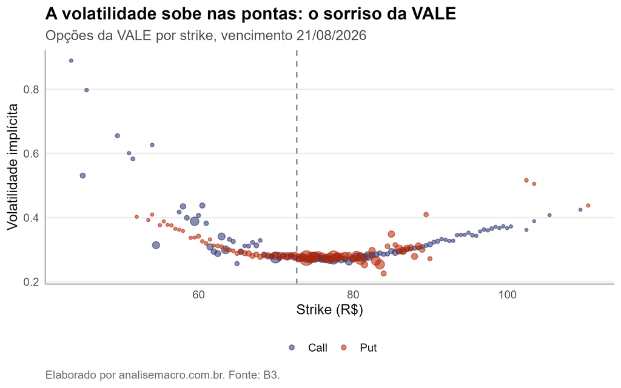

Smile de volatilidade das opções da VALE: a vol implícita é mínima perto do preço à vista e sobe nas asas, para calls e puts.

### 5.2 Volatilidade implícita vs. Delta

Ao mapear a vol implícita contra o Delta, vê-se onde está a liquidez: as bolhas maiores (mais volume) concentram-se ao redor do Delta ±0,50 — as opções *at-the-money*, cujo strike está próximo ao preço da ação.

```r
# Desenha a vol implícita por Delta, do mesmo vencimento âncora
g_delta <- op_vol |>
  # Mantém o mesmo vencimento âncora para comparabilidade
  dplyr::filter(maturity_date == venc_ancora) |>
  # Mapeia Delta no eixo x, vol no y, cor por tipo e tamanho por volume
  ggplot2::ggplot(ggplot2::aes(x = delta, y = impvol, size = volume, color = type)) +
  # Marca o Delta zero (fronteira entre as pontas)
  ggplot2::geom_vline(xintercept = 0, linetype = "dashed", color = "grey50") +
  # Adiciona os pontos com transparência
  ggplot2::geom_point(alpha = 0.55) +
  # Define as cores da marca para call e put
  ggplot2::scale_color_manual(values = c(call = cor_call, put = cor_put),
                              labels = c(call = "Call", put = "Put"), name = NULL) +
  # Esconde a legenda de tamanho
  ggplot2::scale_size_continuous(guide = "none") +
  # Escreve título, rótulos e crédito
  ggplot2::labs(
    x = "Delta", y = "Volatilidade implícita",
    title = "A liquidez se concentra nas opções no dinheiro",
    subtitle = glue::glue("Vol implícita por Delta, vencimento {format(venc_ancora, '%d/%m/%Y')}"),
    caption = caption_am
  ) +
  # Aplica o tema limpo da casa
  tema_am()

# Salva o gráfico de Delta em PNG de alta resolução
ggplot2::ggsave(
  "../imgs/vol-implicita-delta-vale3.png",
  g_delta, width = 8, height = 5, dpi = 300, bg = "white"
)
```

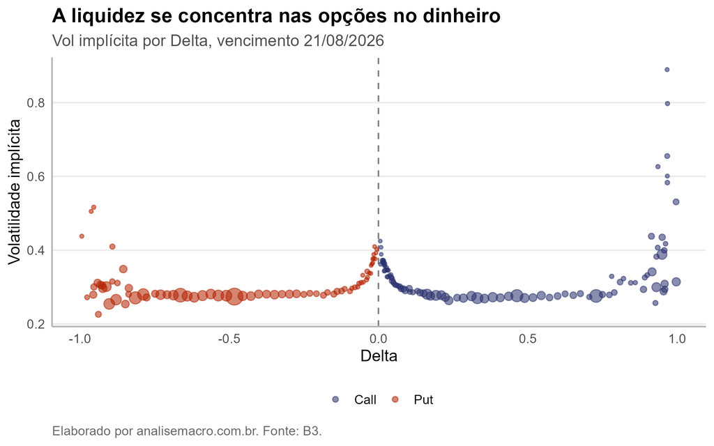

Volatilidade implícita por Delta: a liquidez se concentra nas opções no dinheiro (Delta perto de ±0,5).

### 5.3 Estrutura a termo do smile

O padrão se repete em vários vencimentos, mais nítido onde há mais negócios. Cada painel abaixo é um vencimento; o *smile* aparece em todos, mais limpo quanto maior a liquidez.

```r
# Seleciona os quatro vencimentos com mais strikes negociados
vencs_top4 <- op_vol |>
  # Conta os strikes por vencimento
  dplyr::count(maturity_date, name = "n_strikes") |>
  # Fica com os quatro mais negociados
  dplyr::slice_max(n_strikes, n = 4) |>
  # Ordena por data
  dplyr::arrange(maturity_date) |>
  # Extrai o vetor de datas
  dplyr::pull(maturity_date)

# Desenha a estrutura a termo: um painel de smile por vencimento
g_termo <- op_vol |>
  # Mantém só os quatro vencimentos mais líquidos
  dplyr::filter(maturity_date %in% vencs_top4) |>
  # Rotula cada painel pela data de vencimento
  dplyr::mutate(painel = format(maturity_date, "Vencimento %d/%m/%Y")) |>
  # Mapeia strike no x, vol no y, cor por tipo e tamanho por volume
  ggplot2::ggplot(ggplot2::aes(x = strike_price, y = impvol, size = volume, color = type)) +
  # Marca o preço à vista em cada painel
  ggplot2::geom_vline(xintercept = close_underlying, linetype = "dashed", color = "grey50") +
  # Adiciona os pontos com transparência
  ggplot2::geom_point(alpha = 0.55) +
  # Um painel por vencimento
  ggplot2::facet_wrap(~ painel, scales = "free_x") +
  # Define as cores da marca para call e put
  ggplot2::scale_color_manual(values = c(call = cor_call, put = cor_put),
                              labels = c(call = "Call", put = "Put"), name = NULL) +
  # Esconde a legenda de tamanho
  ggplot2::scale_size_continuous(guide = "none") +
  # Escreve título, rótulos e crédito
  ggplot2::labs(
    x = "Strike (R$)", y = "Volatilidade implícita",
    title = "O sorriso aparece em todos os prazos",
    subtitle = "Smile da VALE nos quatro vencimentos mais negociados",
    caption = caption_am
  ) +
  # Aplica o tema limpo da casa
  tema_am()

# Salva a estrutura a termo em PNG de alta resolução
ggplot2::ggsave(
  "../imgs/estrutura-termo-smile-vale3.png",
  g_termo, width = 9, height = 6, dpi = 300, bg = "white"
)
```

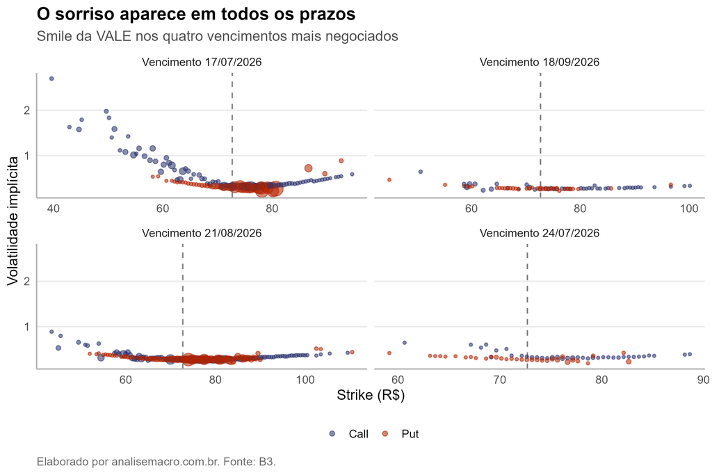

O smile em quatro vencimentos da VALE. O padrão se repete, mais limpo quanto maior a liquidez.

## 6 Conclusão

A precificação de derivativos exige precisão matemática e dados de alta qualidade. Este exercício mostra que o ecossistema R, com pacotes desenvolvidos para as especificidades do mercado brasileiro, permite replicar rotinas de tesourarias institucionais. A extração da volatilidade implícita não só precifica o risco, mas também funciona como um termômetro do sentimento do mercado sobre o futuro de ativos específicos, como a Vale.

#### 6.0.1 Referências

Freitas, W (2022). *oplib: Option Volatility and Pricing Models.* https://github.com/wilsonfreitas/oplib

Freitas, W; Perlin, M (2022). *Download and Parse Public Data Released by B3 Exchange (rb3).* https://github.com/ropensci/rb3

Freitas, W (2023). *bizdays: Business Days Calculations and Utilities.* https://github.com/wilsonfreitas/R-bizdays

Material produzido pela [Análise Macro](https://analisemacro.com.br).